# Anti banknote forgery

Mathematical and Information Sciences III

Dominic Soh (J8190019)

# Introduction

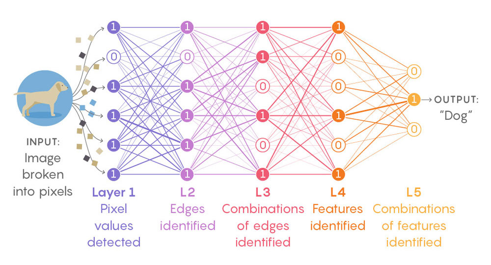

Above is a general example of how a neural network functions. It should take in some inputs, propagate the values down a chain of neurons, and give us an output. The number of features we want to consider from the input would determine the number of neurons we have at the start. At the output, we have the number of neurons equal to the number of outcomes we would like to predict. Backpropagation would be the key component as to how the network learns - correcting its weights and biases for each feature to order to output the correct result.

In this project, we will be analysing a banknote dataset, where we would use 4 variables to predict if the note is genuine or forged in a binary classification problem.

## Packages

```r
#install.packages("caret")
#install.packages("ggplot2")
library(ggplot2)
library(caret)
```

## Dataset

Data for this neural net assignment will be taken from UCI Machine Learning Repository. This data is the banknote authentication Data Set.

The data consists of 4 variables in the first four columns and 1 result in the fifth column. 1. Variance 2. Skewness 3. Curtosis 4. Entropy 5. Type (genuine or fake)

This is a binary classification problem, i.e., predicting 1 or 0 based on the input variable.

```r
banknote.data <- read.csv("https://archive.ics.uci.edu/ml/machine-learning-databases/00267/data_banknote_authentication.txt")

names(banknote.data)[1:5]= c("variance", "skewness", "curtosis", "entropy", "type")
head(banknote.data)
```

|  | variance | skewness | curtosis | entropy | type |
| --- | --- | --- | --- | --- | --- |
| 1 | 4.54590 | 8.1674 | -2.45860 | -1.46210 | 0 |
| 2 | 3.86600 | -2.6383 | 1.92420 | 0.10645 | 0 |
| 3 | 3.45660 | 9.5228 | -4.01120 | -3.59440 | 0 |
| 4 | 0.32924 | -4.4552 | 4.57180 | -0.98880 | 0 |
| 5 | 4.36840 | 9.6718 | -3.96060 | -3.16250 | 0 |
| 6 | 3.59120 | 3.0129 | 0.72888 | 0.56421 | 0 |

|  | variance <dbl> | skewness <dbl> | curtosis <dbl> | entropy <dbl> | type <int> |
| --- | --- | --- | --- | --- | --- |
| 1 | 4.54590 | 8.1674 | -2.45860 | -1.46210 | 0 |
| 2 | 3.86600 | -2.6383 | 1.92420 | 0.10645 | 0 |
| 3 | 3.45660 | 9.5228 | -4.01120 | -3.59440 | 0 |
| 4 | 0.32924 | -4.4552 | 4.57180 | -0.98880 | 0 |
| 5 | 4.36840 | 9.6718 | -3.96060 | -3.16250 | 0 |
| 6 | 3.59120 | 3.0129 | 0.72888 | 0.56421 | 0 |

6 rows

## Data visualisation

Comparing plots of each variable against each other, we see that they are not easily separable. Thus, it might be hard to use linear based methods to predict the outcomes based on their variables.

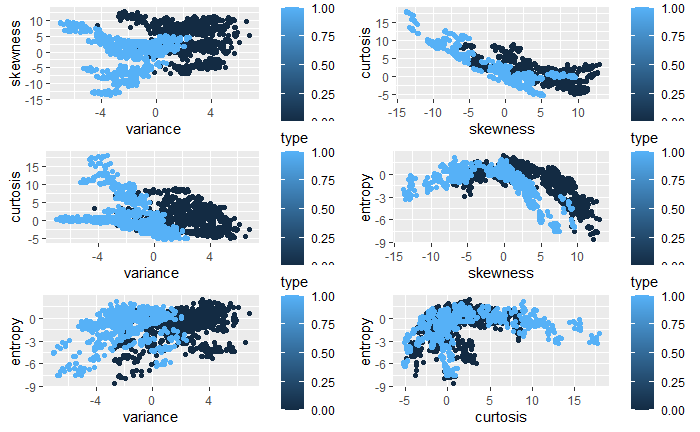

```r
multiplot <- function(..., plotlist=NULL, file, cols=1, layout=NULL) {
  library(grid)

  # Make a list from the ... arguments and plotlist
  plots <- c(list(...), plotlist)

  numPlots = length(plots)

  # If layout is NULL, then use 'cols' to determine layout
  if (is.null(layout)) {
    # Make the panel
    # ncol: Number of columns of plots
    # nrow: Number of rows needed, calculated from # of cols
    layout <- matrix(seq(1, cols * ceiling(numPlots/cols)),
                    ncol = cols, nrow = ceiling(numPlots/cols))
  }

 if (numPlots==1) {
    print(plots[[1]])

  } else {
    # Set up the page
    grid.newpage()
    pushViewport(viewport(layout = grid.layout(nrow(layout), ncol(layout))))

    # Make each plot, in the correct location
    for (i in 1:numPlots) {
      # Get the i,j matrix positions of the regions that contain this subplot
      matchidx <- as.data.frame(which(layout == i, arr.ind = TRUE))

      print(plots[[i]], vp = viewport(layout.pos.row = matchidx$row,
                                      layout.pos.col = matchidx$col))
    }
  }
}
p1<- ggplot(banknote.data, aes(x=variance, y=skewness, color=type)) +geom_point()
p2<- ggplot(banknote.data, aes(x=variance, y=curtosis, color=type)) +geom_point()
p3<- ggplot(banknote.data, aes(x=variance, y=entropy, color=type)) +geom_point()
p4<- ggplot(banknote.data, aes(x=skewness, y=curtosis, color=type)) +geom_point()
p5<- ggplot(banknote.data, aes(x=skewness, y=entropy, color=type)) +geom_point()
p6<- ggplot(banknote.data, aes(x=curtosis, y=entropy, color=type)) +geom_point()
multiplot(p1, p2, p3, p4, p5, p6, cols=2)
```

## Data splitting

The data frame will be split 60/40 to create a `test.set` and a `training.set`. The neural network will train on the `training.set` to adjust the weights and biases as necessary before moving on to the `test.set` to validate the neural network. The accuracy of our predictions on the `test.set` will verify if we overfitted.

We also take the mean of the predicted outcomes for `banknote.data`, `training.set`, and `test.set`, to check for any imbalance in our datasets.

```r
validation.data <- createDataPartition(banknote.data$type, p=0.60, list = FALSE)
test.set <- banknote.data[-validation.data,]
training.set <- banknote.data[validation.data,]
mean(banknote.data$type)
```

```
[1] 0.4449307
```

```r
mean(training.set$type)
```

```
[1] 0.4289186
```

```r
mean(test.set$type)
```

```
[1] 0.4689781
```

## Data processing

Neural networks work best when the input values are standardised. So, we standardise our input variables to obtain a new distribution with mean 0 and standard deviation 1.

Standardising input values speeds up the training and ensures faster convergence.

A common issue with not standardising data is saturation. Given that we would be using tanh and sigmoid functions for our activation functions, if data are not centered around zero, we would get saturation of data points, where all the data would be bunched up on the left or right of zero. This would be highly detrimental to the neural network in terms of training time, as the neural net has to figure out the mean and variances of the data on its own.

The `scale()` function in R allows us to standardise the inputs.

```r
training_variables <- scale(training.set[, c(1:4)])

training_prediction <- training.set$type


test_variables <- scale(test.set[, c(1:4)])

test_prediction <- test.set$type
```

Using `as.matrix()`, we can fill in our input data into matrices. `t()` transposes the matrix.

```r
training_variables <- as.matrix(training_variables, byrow=TRUE)
training_variables <- t(training_variables)
training_prediction <- as.matrix(training_prediction, byrow=TRUE)
training_prediction <- t(training_prediction)

test_variables <- as.matrix(test_variables, byrow=TRUE)
test_variables <- t(test_variables)
test_prediction <- as.matrix(test_prediction, byrow=TRUE)
test_prediction <- t(test_prediction)
```

## Neural network

### Making the network structure

`makelayers` will allow us to construct the strucure of our neural network. `input_neurons`, `hiddenlayer_neurons`, and `output_neurons` will form the input layer, hidden layer, and output layer respectively. To determine the number of neurons needed for each layer, we take the dimensions of the matrices that will pass through them. `input_neurons` thus contain 4 neurons, since we have 4 input variables. `output_neurons` will contain 1 neuron. `hiddenlayer_neurons` will contain as many neurons as we choose later.

```r
makelayers <- function(X, y, hidden_neurons, train=TRUE) {
  input_neurons <- dim(X)[1]
  hiddenlayer_neurons <- hidden_neurons
  output_neurons <- dim(y)[1]

  size <- list("input_neurons" = input_neurons,
               "hiddenlayer_neurons" = hiddenlayer_neurons,
               "output_neurons" = output_neurons)

  return(size)
}
```

### Creating starting parameters

For a 3 layer neural network, we have 2 sets of parameters, `weight1` `bias1` and `weight2` `bias2`, to be adjusted as the network learns.

```r
initializeParameters <- function(X, layer.size){

    m <- dim(data.matrix(X))[2]

    input_neurons <- layer.size$input_neurons
    hiddenlayer_neurons <- layer.size$hiddenlayer_neurons
    output_neurons <- layer.size$output_neurons

    Weight1 <- matrix(runif(hiddenlayer_neurons * input_neurons), nrow = hiddenlayer_neurons, ncol = input_neurons, byrow = TRUE) * 0.01
    bias1 <- matrix(rep(0, hiddenlayer_neurons), nrow = hiddenlayer_neurons)
    Weight2 <- matrix(runif(output_neurons * hiddenlayer_neurons), nrow = output_neurons, ncol = hiddenlayer_neurons, byrow = TRUE) * 0.01
    bias2 <- matrix(rep(0, output_neurons), nrow = output_neurons)

    parameters <- list("Weight1" = Weight1,
                   "bias1" = bias1,
                   "Weight2" = Weight2,
                   "bias2" = bias2)

    return (parameters)
}
```

### Activation

The sigmoid function will serve as our activation function for the output layer. The tanh function will serve as our activation function for the hidden layer.

```r
sigmoid <- function(x){
    return(1 / (1 + exp(-x)))
}
```

### Forward propagation

For forward propagation, we follow the formula:

where F is the activation function.

```r
forwardPropagation <- function(X, parameters, layer.size){

    m <- dim(X)[2]
    hiddenlayer_neurons <- layer.size$hiddenlayer_neurons
    output_neurons <- layer.size$output_neurons

    Weight1 <- parameters$Weight1
    bias1 <- parameters$bias1
    Weight2 <- parameters$Weight2
    bias2 <- parameters$bias2

    bias1_new <- matrix(rep(bias1, m), nrow = hiddenlayer_neurons)
    bias2_new <- matrix(rep(bias2, m), nrow = output_neurons)

    Z1 <- Weight1 %*% X + bias1_new
    A1 <- tanh(Z1)
    Z2 <- Weight2 %*% A1 + bias2_new
    A2 <- sigmoid(Z2)

    cache <- list("Z1" = Z1,
                  "A1" = A1,
                  "Z2" = Z2,
                  "A2" = A2)

    return (cache)
}
```